# Función normal segunda parte

Chaparro, Analía G.

2023-09-19

## Valores aleatorios de una distribución normal

Supongamos que tenemos una distribución normal con media 0 y desvío 1. La variable aleatoria, toma infinitos valores entre $(-\infty;\infty)$.

Vamos a tomar 10 valores de la variables aleatoria en forma aleatoria.

```r
rnorm(10, 0, 1)
```

```
##  [1] -1.30581678 -1.04049827 -1.62372189  0.06015882 -1.95006594  0.95823976
##  [7]  0.15504951  1.20741650 -1.24202005 -0.37144765
```

```r
n <- 10  #tamaño de la muestra
muestra <- rnorm(n, 0, 1)
muestra
```

```
##  [1] -0.9344891 -0.4363571  2.6268225  0.4512500  0.9270267 -0.4003894
##  [7] -0.2302232 -1.6729304  0.7862206 -1.2727375
```

```r
# Convertimos la muestra en un dataframe
muestra <- data.frame(muestra)
```

```r
muestra <- muestra %>%
    arrange(muestra)
muestra
```

```
##       muestra
## 1  -1.6729304
## 2  -1.2727375
## 3  -0.9344891
## 4  -0.4363571
## 5  -0.4003894
## 6  -0.2302232
## 7   0.4512500
## 8   0.7862206
## 9   0.9270267
## 10  2.6268225
```

Para cada valor en la muestra vamos a calcular su probabilidad con pnorm.

Para ello, al dataframe le agregamos una columna que se llame probabilidad. Sugerencia, utilizar la funcion mutate().

```r
data <- muestra %>%
    mutate(Probabilidad = pnorm(muestra, 0, 1))
data
```

```
##       muestra Probabilidad
## 1  -1.6729304    0.0471705
## 2  -1.2727375    0.1015556
## 3  -0.9344891    0.1750258
## 4  -0.4363571    0.3312888
## 5  -0.4003894    0.3444349
## 6  -0.2302232    0.4089592
## 7   0.4512500    0.6740953
## 8   0.7862206    0.7841309
## 9   0.9270267    0.8230437
## 10  2.6268225    0.9956907
```

Calculamos la densidad para cada punto y se lo agregamos al dataframe

```r
data <- data %>%
    mutate(Densidad = dnorm(muestra, 0, 1))
data
```

```
##       muestra Probabilidad   Densidad
## 1  -1.6729304    0.0471705 0.09844212
## 2  -1.2727375    0.1015556 0.17748506
## 3  -0.9344891    0.1750258 0.25779941
## 4  -0.4363571    0.3312888 0.36271340
## 5  -0.4003894    0.3444349 0.36821275
## 6  -0.2302232    0.4089592 0.38850863
## 7   0.4512500    0.6740953 0.36032393
## 8   0.7862206    0.7841309 0.29287483
## 9   0.9270267    0.8230437 0.25959623
## 10  2.6268225    0.9956907 0.01266343
```

Mostramos en tabla el dataframe

```r
data %>%
    kbl() %>%
    kable_styling(full_width = F)
```

| muestra | Probabilidad | Densidad |
| --- | --- | --- |
| -1.6729304 | 0.0471705 | 0.0984421 |
| -1.2727375 | 0.1015556 | 0.1774851 |
| -0.9344891 | 0.1750258 | 0.2577994 |
| -0.4363571 | 0.3312888 | 0.3627134 |
| -0.4003894 | 0.3444349 | 0.3682127 |
| -0.2302232 | 0.4089592 | 0.3885086 |
| 0.4512500 | 0.6740953 | 0.3603239 |
| 0.7862206 | 0.7841309 | 0.2928748 |
| 0.9270267 | 0.8230437 | 0.2595962 |
| 2.6268225 | 0.9956907 | 0.0126634 |

Calculamos el desvío y la media de la muestra

```r
x_raya <- mean(data$muestra)
s_d <- sd(data$muestra)
```

Lo presentamos en un cuadro de salida

```r
resumen_data <- data.frame(Tamaño_muestral = n, Media_muestral = x_raya, Desvio_muestral = s_d)
resumen_data <- resumen_data %>%
    mutate(Numero_muestra = nrow(resumen_data))
# reordeno
resumen_data <- resumen_data %>%
    select(Numero_muestra, Tamaño_muestral, Media_muestral, Desvio_muestral)
resumen_data %>%
    kbl() %>%
    kable_styling(full_width = F)
```

| Numero_muestra | Tamaño_muestral | Media_muestral | Desvio_muestral |
| --- | --- | --- | --- |
| 1 | 10 | -0.0155807 | 1.259385 |

Graficamos la probabilidad vs los cuantiles

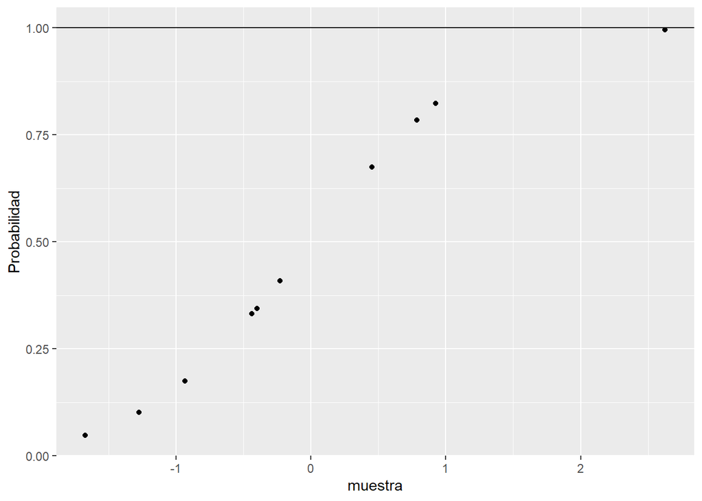

```r
g1 <- ggplot(data = data, mapping = aes(x = muestra, y = Probabilidad)) + geom_point() +
    geom_hline(yintercept = 1)
g1
```

Graficamos la densidad en funcion de los puntos muestrales.

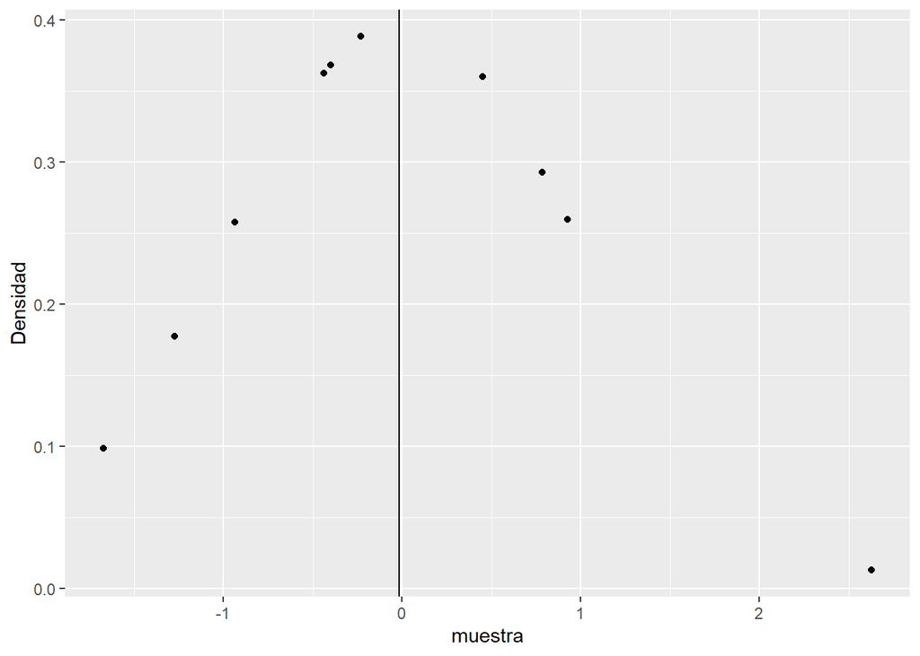

```r
g2 <- ggplot(data = data, mapping = aes(x = muestra, y = Densidad)) + geom_point() +
    geom_vline(xintercept = x_raya)
g2
```

Repetimos todo, tomando 10 muestras de tamaño 100.

Necesitamos de una función que nos ayude con las muestras y organice un dataframe que registre para cada muestra tomada, su media y desvío.

```r
resumen = function(n, mu, sigma) {
    muestra = rnorm(n, mu, sigma)
    media_muestral = mean(muestra)
    desvio_muestral = sd(muestra)
    return(salida = data.frame(media_muestral = media_muestral, desvio_muestral = desvio_muestral))
}
```

```r
m1 <- resumen(100, 0, 1)
m2 <- resumen(100, 0, 1)
m3 <- resumen(100, 0, 1)
m4 <- resumen(100, 0, 1)
m5 <- resumen(100, 0, 1)
m6 <- resumen(100, 0, 1)
m7 <- resumen(100, 0, 1)
m8 <- resumen(100, 0, 1)
m9 <- resumen(100, 0, 1)
m10 <- resumen(100, 0, 1)
res <- rbind(m1, m2, m3, m4, m5, m6, m7, m8, m9, m10)
res <- res %>%
    mutate(muestra_numero = 1:nrow(res)) %>%
    dplyr::arrange(media_muestral)

res %>%
    kbl() %>%
    kable_styling(full_width = F)
```

| media_muestral | desvio_muestral | muestra_numero |
| --- | --- | --- |
| -0.1258346 | 1.1142442 | 9 |
| -0.0926124 | 1.0379415 | 7 |
| -0.0642554 | 0.9879867 | 6 |
| -0.0577403 | 1.0097423 | 4 |
| -0.0341990 | 0.8576478 | 8 |
| -0.0153370 | 1.0696174 | 10 |
| -0.0127470 | 1.0217628 | 2 |
| 0.0123323 | 1.0971268 | 5 |
| 0.0327007 | 0.9185687 | 3 |
| 0.1691035 | 0.9320647 | 1 |

Graficamos un histograma de las medias…

```r
g <- ggplot(data = res, mapping = aes(x = media_muestral)) + geom_histogram(aes(y = ..density..),
    colour = 1, fill = "lightblue") + geom_density(lwd = 1, colour = 4)
```

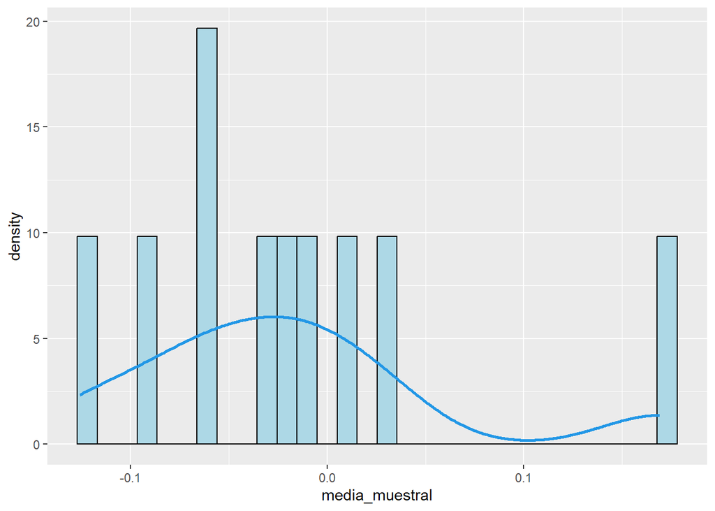

```r
g
```

Qué pasa si queremos repetir este proceso 100 veces? tomar 100 muestras de tamaño 10 o de tamaño 100 o de tamaño 1000?

## Simulación de una variable aleatoria especial

Definamos una función que haga esta simulación…

```r
# Definimos la función que realiza las iteraciones
simulacion <- function(I, n, mu, sigma) {
    # En primer lugar, definimos la función resumen, dentro de la funcion
    # generalizadora

    resumen = function(n, mu, sigma) {
        muestra = rnorm(n, mu, sigma)
        media_muestral = mean(muestra)
        desvio_muestral = sd(muestra)
        return(salida = data.frame(media_muestral = media_muestral, desvio_muestral = desvio_muestral))
    }

    # Creaamos un Dataframe vacío para almacenar los resultados
    resultado <- data.frame()
    # Creamos un ciclo for que en cada iteracción, genere una muestra y calcule
    for (i in 1:I) {
        # Llamamos a la función resumen y obtenemos el dataframe en cada
        # iteracion
        df <- resumen(n, mu, sigma)
        # Unificamos el Dataframe actual con el dataframe vacío llamado
        # resultado
        resultado <- rbind(resultado, df)

    }

    # Reiniciamos los índices del Dataframe resultado
    rownames(resultado) <- NULL
    # Agregamos una columna con el tamaño muestral
    resultado <- resultado %>%
        mutate(Muestreo_numero = 1:nrow(resultado))
    # Reordenamos las columnas del dataframe
    resultado <- resultado %>%
        select(Muestreo_numero, media_muestral, desvio_muestral)

    return(resultado)
}
```

Ahora aplicamos la función generalizadora para tomar 1000 muestras de tamaño 10, de la variable normal con media $\mu=0$ y desvío $\sigma=1$

```r
I <- 1000  #cantidad de iteraciones
n <- 10  #tamaño de muestra
mu <- 0
sigma <- 1
m <- simulacion(I, n, mu, sigma)
head(m)
```

```
##   Muestreo_numero media_muestral desvio_muestral
## 1               1    0.056139761       1.1373697
## 2               2    0.004132874       0.5748030
## 3               3   -0.082572188       1.0604397
## 4               4   -0.160055668       0.7700694
## 5               5   -0.272317758       0.9570052
## 6               6    0.177151262       0.7704807
```

Graficamos un histograma de las medias…

```r
g <- ggplot(data = m, mapping = aes(x = media_muestral)) + geom_histogram(aes(y = ..density..),
    colour = 1, fill = "lightblue") + geom_density(lwd = 1, colour = 4)
```

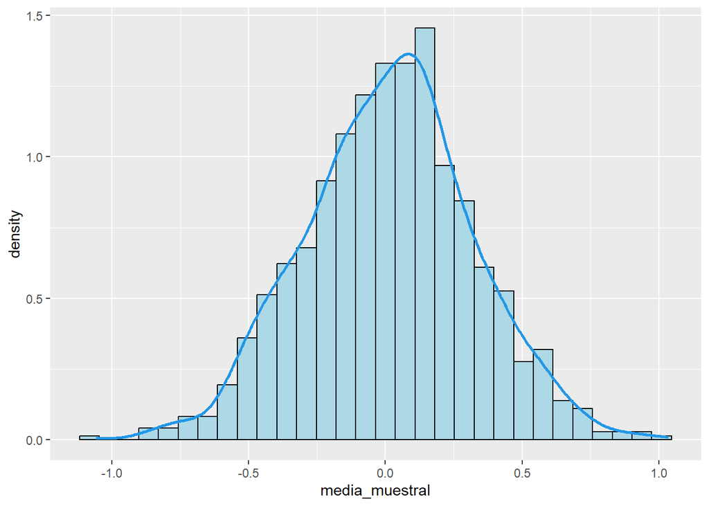

```r
g
```

Repetimos: tomar 1000 muestras de tamaño 100, de la variable normal con media $\mu=0$ y desvío $\sigma=1$.

```r
I <- 1000  #cantidad de iteraciones
n <- 100  #tamaño de muestra
mu <- 0
sigma <- 1
m <- simulacion(I, n, mu, sigma)
head(m)
```

```
##   Muestreo_numero media_muestral desvio_muestral
## 1               1     0.14507285       0.9611357
## 2               2    -0.04483706       0.9926321
## 3               3     0.05839019       1.0631556
## 4               4     0.09710213       1.0553427
## 5               5     0.02157038       1.1693834
## 6               6     0.18996814       0.9340092
```

Graficamos un histograma de las medias

```r
g <- ggplot(data = m, mapping = aes(x = media_muestral)) + geom_histogram(aes(y = ..density..),
    colour = 1, fill = "lightblue") + geom_density(lwd = 1, colour = 4)
```

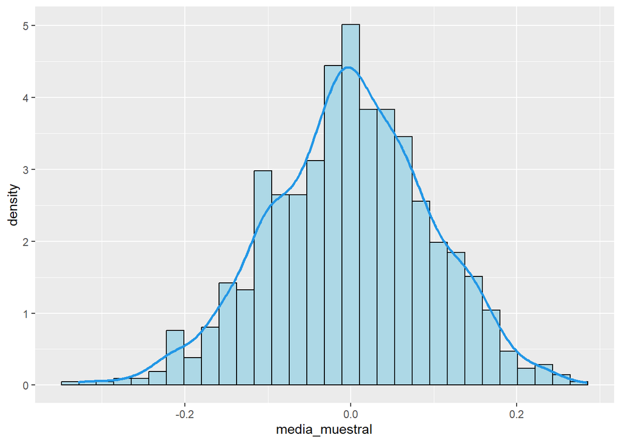

```r
g
```

Con estos ejemplos, observamos que cada muestra aporta un valor de media. Los valores de media, tienden a distribuirse normalmente.

Esto nos conduce a pensar que la media es una variable aleatoria que se distribuye normalmente.